# 2023-08-08_Finance_Random_Forest_ slides

[figure not shown]

**Random Forest Applications in Finance**

**Applications des Forêts Aléatoires en Finance**

(EN) Predicting Tomorrow's S&P Index Price

(FR) Prédiction du prix de l'indice S&P de demain

| Eder Valderrama | eder.valderrama@usp.br | 2023 |
| --- | --- | --- |

(EN) Importing Packages

(FR) Importation de packages

```python
import os
import pandas as pd
import matplotlib as plt
import yfinance as yf
from sklearn.ensemble import RandomForestClassifier
from sklearn.metrics import precision_score
from sklearn.model_selection import train_test_split
from sklearn.metrics import accuracy_score, classification_report
from sklearn.model_selection import GridSearchCV
```

Downloading Financial Data

Téléchargement de données financières

```python
if os.path.exists("sp500.csv"):
    sp500 = pd.read_csv("sp500.csv", index_col=0)
else:
    sp500 = yf.Ticker("^GSPC")
    sp500 = sp500.history(period="max")
    sp500.to_csv("sp500.csv")
```

```python
sp500.index = pd.to_datetime(sp500.index)
```

```python
sp500.head()
```

| Date | Open | High | Low | Close | Volume | Dividends | Stock Splits |
| --- | --- | --- | --- | --- | --- | --- | --- |
| 1927-12-30 00:00:00-05:00 | 17.660000 | 17.660000 | 17.660000 | 17.660000 | 0 | 0.0 | 0.0 |
| 1928-01-03 00:00:00-05:00 | 17.760000 | 17.760000 | 17.760000 | 17.760000 | 0 | 0.0 | 0.0 |
| 1928-01-04 00:00:00-05:00 | 17.719999 | 17.719999 | 17.719999 | 17.719999 | 0 | 0.0 | 0.0 |
| 1928-01-05 00:00:00-05:00 | 17.549999 | 17.549999 | 17.549999 | 17.549999 | 0 | 0.0 | 0.0 |
| 1928-01-06 00:00:00-05:00 | 17.660000 | 17.660000 | 17.660000 | 17.660000 | 0 | 0.0 | 0.0 |

```python
sp500.index
```

```
Index([1927-12-30 00:00:00-05:00, 1928-01-03 00:00:00-05:00,
       1928-01-04 00:00:00-05:00, 1928-01-05 00:00:00-05:00,
       1928-01-06 00:00:00-05:00, 1928-01-09 00:00:00-05:00,
       1928-01-10 00:00:00-05:00, 1928-01-11 00:00:00-05:00,
       1928-01-12 00:00:00-05:00, 1928-01-13 00:00:00-05:00,
       ...
       2023-07-25 00:00:00-04:00, 2023-07-26 00:00:00-04:00,
       2023-07-27 00:00:00-04:00, 2023-07-28 00:00:00-04:00,
       2023-07-31 00:00:00-04:00, 2023-08-01 00:00:00-04:00,
       2023-08-02 00:00:00-04:00, 2023-08-03 00:00:00-04:00,
       2023-08-04 00:00:00-04:00, 2023-08-07 00:00:00-04:00],
      dtype='object', name='Date', length=24014)
```

Visualizing Data

Visualisation des données

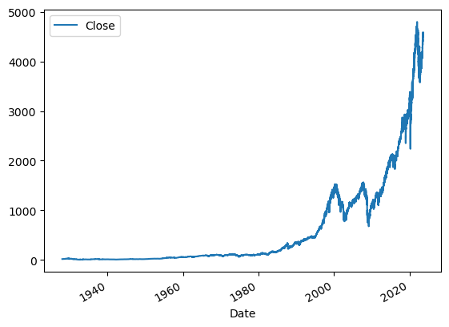

```python
sp500.plot.line(y='Close', use_index=True)
```

Data Cleaning

Nettoyage des données

```python
del sp500['Dividends']
del sp500['Stock Splits']
```

```python
sp500.columns
```

```
Index(['Open', 'High', 'Low', 'Close', 'Volume'], dtype='object')
```

Setting Up Target Data for Machine Learning

Mise en place des données cibles pour l'apprentissage automatique

```python
sp500['Tomorrow'] = sp500['Close'].shift(-1)
```

```python
sp500.head()
```

| Date | Open | High | Low | Close | Volume | Tomorrow |
| --- | --- | --- | --- | --- | --- | --- |
| 1927-12-30 00:00:00-05:00 | 17.660000 | 17.660000 | 17.660000 | 17.660000 | 0 | 17.760000 |
| 1928-01-03 00:00:00-05:00 | 17.760000 | 17.760000 | 17.760000 | 17.760000 | 0 | 17.719999 |
| 1928-01-04 00:00:00-05:00 | 17.719999 | 17.719999 | 17.719999 | 17.719999 | 0 | 17.549999 |
| 1928-01-05 00:00:00-05:00 | 17.549999 | 17.549999 | 17.549999 | 17.549999 | 0 | 17.660000 |
| 1928-01-06 00:00:00-05:00 | 17.660000 | 17.660000 | 17.660000 | 17.660000 | 0 | 17.500000 |

```python
sp500.tail()
```

| Date | Open | High | Low | Close | Volume | Tomorrow |
| --- | --- | --- | --- | --- | --- | --- |
| 2023-08-01 00:00:00-04:00 | 4578.830078 | 4584.620117 | 4567.529785 | 4576.729980 | 4042370000 | 4513.390137 |
| 2023-08-02 00:00:00-04:00 | 4550.930176 | 4550.930176 | 4505.750000 | 4513.390137 | 4270710000 | 4501.890137 |
| 2023-08-03 00:00:00-04:00 | 4494.270020 | 4519.490234 | 4485.540039 | 4501.890137 | 4149120000 | 4478.029785 |
| 2023-08-04 00:00:00-04:00 | 4513.959961 | 4540.339844 | 4474.549805 | 4478.029785 | 4143310000 | 4518.439941 |
| 2023-08-07 00:00:00-04:00 | 4491.580078 | 4519.839844 | 4491.149902 | 4518.439941 | 3493920000 | NaN |

Comparing Data to Find Opportunities

Comparer les données pour trouver des opportunités

Days with a 'tomorrow' value higher than the 'close' value Tendency for value elevation

Jours avec une valeur 'demain' supérieure à la valeur 'clôture' Tendance à l'élévation de la valeur

- sp500['Target'] = sp500['Tomorrow'] > sp500['Close']
- 0: sp500['Tomorrow'] <= sp500['Close']
- 1: sp500['Tomorrow'] > sp500['Close']

```python
sp500['Target'] = sp500['Tomorrow'] > sp500['Close']
```

```python
sp500['Target'] = sp500['Target'].astype(int)
```

```python
sp500.head()
```

| Date | Open | High | Low | Close | Volume | Tomorrow | Target |
| --- | --- | --- | --- | --- | --- | --- | --- |
| 1927-12-30 00:00:00-05:00 | 17.660000 | 17.660000 | 17.660000 | 17.660000 | 0 | 17.760000 | 1 |
| 1928-01-03 00:00:00-05:00 | 17.760000 | 17.760000 | 17.760000 | 17.760000 | 0 | 17.719999 | 0 |
| 1928-01-04 00:00:00-05:00 | 17.719999 | 17.719999 | 17.719999 | 17.719999 | 0 | 17.549999 | 0 |
| 1928-01-05 00:00:00-05:00 | 17.549999 | 17.549999 | 17.549999 | 17.549999 | 0 | 17.660000 | 1 |
| 1928-01-06 00:00:00-05:00 | 17.660000 | 17.660000 | 17.660000 | 17.660000 | 0 | 17.500000 | 0 |

The older stock market values have less precision for predictions.

- Establishing the Cut-off Point for Predictions.

Les anciennes valeurs du marché boursier ont moins de précision pour les prédictions.

- Établissement du moment de coupure pour les prédictions.The older values of stock market have less precision for predictions

```python
start_date = pd.Timestamp('1990-01-01', tz='UTC')
```

```python
sp500_selected = sp500[sp500.index >= start_date].copy()
```

```python
sp500_selected
```

| Date | Open | High | Low | Close | Volume | Tomorrow | Target |
| --- | --- | --- | --- | --- | --- | --- | --- |
| 1990-01-02 00:00:00-05:00 | 353.399994 | 359.690002 | 351.980011 | 359.690002 | 162070000 | 358.760010 | 0 |
| 1990-01-03 00:00:00-05:00 | 359.690002 | 360.589996 | 357.890015 | 358.760010 | 192330000 | 355.670013 | 0 |
| 1990-01-04 00:00:00-05:00 | 358.760010 | 358.760010 | 352.890015 | 355.670013 | 177000000 | 352.200012 | 0 |
| 1990-01-05 00:00:00-05:00 | 355.670013 | 355.670013 | 351.350006 | 352.200012 | 158530000 | 353.790009 | 1 |
| 1990-01-08 00:00:00-05:00 | 352.200012 | 354.239990 | 350.540009 | 353.790009 | 140110000 | 349.619995 | 0 |
| ... | ... | ... | ... | ... | ... | ... | ... |
| 2023-08-01 00:00:00-04:00 | 4578.830078 | 4584.620117 | 4567.529785 | 4576.729980 | 4042370000 | 4513.390137 | 0 |
| 2023-08-02 00:00:00-04:00 | 4550.930176 | 4550.930176 | 4505.750000 | 4513.390137 | 4270710000 | 4501.890137 | 0 |
| 2023-08-03 00:00:00-04:00 | 4494.270020 | 4519.490234 | 4485.540039 | 4501.890137 | 4149120000 | 4478.029785 | 0 |
| 2023-08-04 00:00:00-04:00 | 4513.959961 | 4540.339844 | 4474.549805 | 4478.029785 | 4143310000 | 4518.439941 | 1 |
| 2023-08-07 00:00:00-04:00 | 4491.580078 | 4519.839844 | 4491.149902 | 4518.439941 | 3493920000 | NaN | 0 |

8464 rows × 7 columns

Training the Initial Machine Learning Model - Random Forest

Entraînement du modèle initial d'apprentissage automatique - Forêt aléatoire

Parameters for RandomForestClassifier:

Paramètres pour RandomForestClassifier :

- n_estimators=100
- min_samples_split=100

```python
%%time
model = RandomForestClassifier(n_estimators=100,
                              min_samples_split=100,
                              random_state=1)
```

```
CPU times: total: 0 ns
Wall time: 0 ns
```

```python
train = sp500_selected.iloc[:-100]
```

```python
test = sp500_selected.iloc[-100:]
```

```python
predictors = ['Close', 'Volume', 'Open', 'High', 'Low']
```

```python
%%time
model.fit(X=train[predictors], y=train['Target'])
```

```
CPU times: total: 5.2 s
Wall time: 5.38 s
```

```
RandomForestClassifier(min_samples_split=100, random_state=1)
```

```python
preds = model.predict(test[predictors])
```

```python
preds
```

```
array([0, 1, 0, 1, 0, 0, 0, 0, 0, 0, 0, 0, 0, 0, 0, 0, 0, 0, 0, 1, 0, 1,
       1, 0, 1, 1, 1, 0, 0, 0, 0, 0, 0, 0, 0, 0, 0, 1, 1, 0, 1, 0, 1, 1,
       0, 0, 0, 1, 0, 1, 0, 1, 0, 0, 1, 1, 1, 1, 1, 1, 1, 1, 1, 1, 1, 0,
       1, 1, 1, 0, 0, 1, 1, 1, 1, 0, 1, 1, 1, 0, 1, 1, 1, 1, 1, 1, 1, 1,
       1, 1, 1, 1, 1, 1, 1, 1, 1, 1, 1, 1])
```

```python
preds = pd.Series(preds, index=test.index)
```

```python
preds
```

```
Date
2023-03-15 00:00:00-04:00    0
2023-03-16 00:00:00-04:00    1
2023-03-17 00:00:00-04:00    0
2023-03-20 00:00:00-04:00    1
2023-03-21 00:00:00-04:00    0
                            ..
2023-08-01 00:00:00-04:00    1
2023-08-02 00:00:00-04:00    1
2023-08-03 00:00:00-04:00    1
2023-08-04 00:00:00-04:00    1
2023-08-07 00:00:00-04:00    1
Length: 100, dtype: int32
```

```python
precision_score(test['Target'], preds)
```

```
0.5964912280701754
```

```python
combined = pd.concat([test["Target"], preds], axis=1)
```

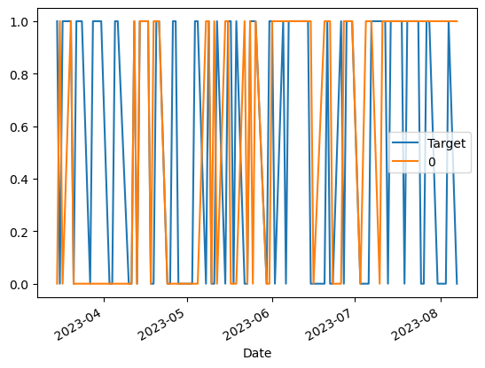

```python
combined.plot()
```

Building a Backtesting System

Construction d'un système de rétrotestage

```python
def predict(train, test, predictors, model):
    # Fitting of the model
    model.fit(train[predictors], train["Target"])

    # predictions
    preds = model.predict(test[predictors])
    preds = pd.Series(preds, index=test.index, name="Predictions")
    combined = pd.concat([test["Target"], preds], axis=1)
    return combined
```

- Start value: Assuming a trading year with approximately 250 days
- 2500 data points represent almost 10 years of data
- Valeur de départ : En supposant une année de trading avec environ 250 jours
- 2500 points de données représentent près de 10 ans de données

```python
def backtest(data, model, predictors, start=2500, step=250):
    all_predictions = []
    # Predicting year by year, excluding the first 10 years.
    # Prédiction année par année, en excluant les 10 premières années.
    for i in range(start, data.shape[0], step):
        train = data.iloc[0:i].copy()
        test = data.iloc[i:(i+step)].copy()
        predictions = predict(train, test, predictors, model)
        all_predictions.append(predictions)
    return pd.concat(all_predictions)
```

```python
%%time
predictions = backtest(sp500_selected, model, predictors)
```

```
CPU times: total: 1min 6s
Wall time: 1min 9s
```

Evaluation of Prediction Errors

Évaluation des erreurs de prédiction

- 0: sp500['Tomorrow'] <= sp500['Close']
- 1: sp500['Tomorrow'] > sp500['Close']

```python
%%time
predictions['Predictions'].value_counts()
```

```
CPU times: total: 0 ns
Wall time: 11.1 ms
```

```
0    3433
1    2531
Name: Predictions, dtype: int64
```

Precision of the Predictions

Précision des prédictions

- Approximately 53%
- Environ 53%

```python
%%time
precision_score(predictions['Target'], predictions['Predictions'])
```

```
CPU times: total: 31.2 ms
Wall time: 35.7 ms
```

```
0.5298301066772027
```

To establish if the result is good or not:

- Define a benchmark: Identify the days when the market actually went up.

Pour déterminer si le résultat est bon ou non :

- Définir un point de référence : Identifier les jours où le marché a effectivement augmenté.

```python
%%time
evaluation = predictions['Target'].value_counts() / predictions.shape[0]
```

```
CPU times: total: 0 ns
Wall time: 997 µs
```

```python
evaluation
```

```
1    0.534038
0    0.465962
Name: Target, dtype: float64
```

```python
benchmark_tomorrow_bigger_today = evaluation.iloc[0]
benchmark_tomorrow_bigger_today
```

```
0.534037558685446
```

Since the prediction accuracy (52.9%) is worse than the benchmark (reality: close to 53.4%), it becomes necessary to enhance the model.

Étant donné que la précision de prédiction (52,9 %) est inférieure au point de référence (réalité : près de 53,4 %), il est nécessaire d'améliorer le modèle.

Adapting the model to achieve better accuracy than the benchmark.

Adapter le modèle pour obtenir une meilleure précision que le point de référence.

Utilizing Rolling Averages for Improvement:

Utilisation des moyennes mobiles pour améliorer :

Using Trading Days:

- 2: The last 2 days' values
- 5: The last 5 days' or the last 1 week's values
- 60: The last 3 months' values
- 250: The last 1 year's values
- 1000: The last 4 years' values

En utilisant les jours de trading :

- 2 : Les valeurs des 2 derniers jours
- 5 : Les valeurs des 5 derniers jours ou de la dernière semaine
- 60 : Les valeurs des 3 derniers mois
- 250 : Les valeurs de la dernière année
- 1000 : Les valeurs des 4 dernières années

```python
horizons = [2, 5, 60, 250, 1000]
```

Adding Additional Predictors to the Model:

Calculating the ratio between today's price and the price for each specified period. Determining the trend direction (up or down) for prices.

Ajout de prédicteurs supplémentaires au modèle :

Calculer le ratio entre le prix d'aujourd'hui et le prix pour chaque période spécifiée. Déterminer la tendance (hausse ou baisse) des prix.

```python
new_predictors = []
```

```python
%%time
for horizon_i in horizons:
    rolling_average = sp500_selected.rolling(horizon_i).mean()

    ratio_column = f'Close_Ratio_{horizon_i}'
    sp500_selected[ratio_column] = sp500_selected['Close'] / rolling_average['Close']

    trend_column = f'Trend_{horizon_i}'
    sp500_selected[trend_column] = sp500_selected.shift(1).rolling(horizon_i).sum()['Target']

    new_predictors += [ratio_column, trend_column]
```

```
CPU times: total: 46.9 ms
Wall time: 75.8 ms
```

Creating New Columns with Rolling Averages

Création de nouvelles colonnes avec des moyennes mobiles

```python
sp500_selected.shape
```

```
(8464, 17)
```

```python
sp500_selected.head()
```

| Date | Open | High | Low | Close | Volume | Tomorrow | Target | Close_Ratio_2 | Trend_2 | Close_Ratio_5 | Trend_5 | Close_Ratio_60 | Trend_60 | Close_Ratio_250 | Trend_250 | Close_Ratio_1000 | Trend_1000 |
| --- | --- | --- | --- | --- | --- | --- | --- | --- | --- | --- | --- | --- | --- | --- | --- | --- | --- |
| 1990-01-02 00:00:00-05:00 | 353.399994 | 359.690002 | 351.980011 | 359.690002 | 162070000 | 358.760010 | 0 | NaN | NaN | NaN | NaN | NaN | NaN | NaN | NaN | NaN | NaN |
| 1990-01-03 00:00:00-05:00 | 359.690002 | 360.589996 | 357.890015 | 358.760010 | 192330000 | 355.670013 | 0 | 0.998706 | NaN | NaN | NaN | NaN | NaN | NaN | NaN | NaN | NaN |
| 1990-01-04 00:00:00-05:00 | 358.760010 | 358.760010 | 352.890015 | 355.670013 | 177000000 | 352.200012 | 0 | 0.995675 | 0.0 | NaN | NaN | NaN | NaN | NaN | NaN | NaN | NaN |
| 1990-01-05 00:00:00-05:00 | 355.670013 | 355.670013 | 351.350006 | 352.200012 | 158530000 | 353.790009 | 1 | 0.995098 | 0.0 | NaN | NaN | NaN | NaN | NaN | NaN | NaN | NaN |
| 1990-01-08 00:00:00-05:00 | 352.200012 | 354.239990 | 350.540009 | 353.790009 | 140110000 | 349.619995 | 0 | 1.002252 | 1.0 | 0.993731 | NaN | NaN | NaN | NaN | NaN | NaN | NaN |

Cleaning Data of Missing Values

Nettoyage des données des valeurs manquantes

```python
sp500_selected = sp500_selected.dropna()
```

The new dataset begins in 1993.

Le nouveau jeu de données débute en 1993.

```python
sp500_selected.head()
```

| Date | Open | High | Low | Close | Volume | Tomorrow | Target | Close_Ratio_2 | Trend_2 | Close_Ratio_5 | Trend_5 | Close_Ratio_60 | Trend_60 | Close_Ratio_250 | Trend_250 | Close_Ratio_1000 | Trend_1000 |
| --- | --- | --- | --- | --- | --- | --- | --- | --- | --- | --- | --- | --- | --- | --- | --- | --- | --- |
| 1993-12-14 00:00:00-05:00 | 465.730011 | 466.119995 | 462.459991 | 463.059998 | 275050000 | 461.839996 | 0 | 0.997157 | 1.0 | 0.996617 | 1.0 | 1.000283 | 32.0 | 1.028047 | 127.0 | 1.176082 | 512.0 |
| 1993-12-15 00:00:00-05:00 | 463.059998 | 463.690002 | 461.839996 | 461.839996 | 331770000 | 463.339996 | 1 | 0.998681 | 0.0 | 0.995899 | 1.0 | 0.997329 | 32.0 | 1.025151 | 126.0 | 1.172676 | 512.0 |
| 1993-12-16 00:00:00-05:00 | 461.859985 | 463.980011 | 461.859985 | 463.339996 | 284620000 | 466.380005 | 1 | 1.001621 | 1.0 | 0.999495 | 2.0 | 1.000311 | 32.0 | 1.028274 | 127.0 | 1.176163 | 513.0 |
| 1993-12-17 00:00:00-05:00 | 463.339996 | 466.380005 | 463.339996 | 466.380005 | 363750000 | 465.850006 | 0 | 1.003270 | 2.0 | 1.004991 | 3.0 | 1.006561 | 32.0 | 1.034781 | 128.0 | 1.183537 | 514.0 |
| 1993-12-20 00:00:00-05:00 | 466.380005 | 466.899994 | 465.529999 | 465.850006 | 255900000 | 465.299988 | 0 | 0.999431 | 1.0 | 1.003784 | 2.0 | 1.005120 | 32.0 | 1.033359 | 128.0 | 1.181856 | 513.0 |

```python
sp500_selected.shape
```

```
(7463, 17)
```

Improving the Model

- New Parameters for RandomForestClassifier:

Amélioration du modèle

- Nouveaux paramètres pour RandomForestClassifier :

```
- n_estimators=200
- min_samples_split=50
```

```python
%%time
model = RandomForestClassifier(n_estimators=200,
                               min_samples_split=50,
                              random_state=1)
```

```
CPU times: total: 0 ns
Wall time: 0 ns
```

```python
def predict(train, test, predictors, model):
    model.fit(train[predictors], train["Target"])
    # Enhancing control to establish how to generate 1 and 0 values
    # based on the probability of the price going up.
    # Améliorer le contrôle pour établir comment générer les valeurs 1 et 0
    # en fonction de la probabilité que le prix augmente.
    preds = model.predict_proba(test[predictors])[:,1]
    # Threshold - Impact to Reduce the Number of Trading Days
    # Indicates the days when making a trade is a genuine opportunity
    # Seuil - Impact pour réduire le nombre de jours de trading
    # Indique les jours où effectuer un échange est une véritable opportunité
    preds[preds >=.6] = 1
    preds[preds <.6] = 0
    preds = pd.Series(preds, index=test.index, name="Predictions")
    combined = pd.concat([test["Target"], preds], axis=1)
    return combined
```

For backtesting, the crucial information is the percentage variation.

Pour le rétrotestage, l'information importante est la variation en pourcentage.

```python
%%time
predictions = backtest(sp500_selected, model, new_predictors)
```

```
CPU times: total: 1min 7s
Wall time: 1min 11s
```

Predicting a small number of days as "1".

Prédire un petit nombre de jours comme étant "1".

- 0 : sp500['Tomorrow'] <= sp500['Close']
- 1 : sp500['Tomorrow'] > sp500['Close']

```python
%%time
predictions["Predictions"].value_counts()
```

```
CPU times: total: 0 ns
Wall time: 2.7 ms
```

```
0.0    4144
1.0     819
Name: Predictions, dtype: int64
```

The precision of the predictions has improved now.

La précision des prédictions est maintenant meilleure.

```python
%%time
precision_score(predictions["Target"], predictions["Predictions"])
```

```
CPU times: total: 0 ns
Wall time: 7.6 ms
```

```
0.568986568986569
```

To establish if the result is good or not:

- Define a benchmark: Identify the days when the market actually went up.

Pour déterminer si le résultat est bon ou non :

- Définir un point de référence : Identifier les jours où le marché a effectivement augmenté.

```python
%%time
predictions["Target"].value_counts() / predictions.shape[0]
```

```
CPU times: total: 0 ns
Wall time: 0 ns
```

```
1    0.544026
0    0.455974
Name: Target, dtype: float64
```

Since the prediction values are better than the benchmark, it is possible to conclude that there is a reliable forecasting method.

Étant donné que les valeurs de prédiction sont meilleures que le point de référence, il est possible de conclure qu'il existe une méthode de prévision fiable.

```python
%%time
predictions
```

```
CPU times: total: 0 ns
Wall time: 0 ns
```

| Date | Target | Predictions |
| --- | --- | --- |
| 2003-11-14 00:00:00-05:00 | 0 | 0.0 |
| 2003-11-17 00:00:00-05:00 | 0 | 1.0 |
| 2003-11-18 00:00:00-05:00 | 1 | 1.0 |
| 2003-11-19 00:00:00-05:00 | 0 | 0.0 |
| 2003-11-20 00:00:00-05:00 | 1 | 1.0 |
| ... | ... | ... |
| 2023-07-31 00:00:00-04:00 | 0 | 0.0 |
| 2023-08-01 00:00:00-04:00 | 0 | 0.0 |
| 2023-08-02 00:00:00-04:00 | 0 | 0.0 |
| 2023-08-03 00:00:00-04:00 | 0 | 1.0 |
| 2023-08-04 00:00:00-04:00 | 1 | 1.0 |

4963 rows × 2 columns

Separating Features and Target

Séparation des caractéristiques et de la cible

```python
columns_to_feature = sp500_selected.columns.drop('Target')
columns_to_feature
```

```
Index(['Open', 'High', 'Low', 'Close', 'Volume', 'Tomorrow', 'Close_Ratio_2',
       'Trend_2', 'Close_Ratio_5', 'Trend_5', 'Close_Ratio_60', 'Trend_60',
       'Close_Ratio_250', 'Trend_250', 'Close_Ratio_1000', 'Trend_1000'],
      dtype='object')
```

```python
features = sp500_selected[columns_to_feature]
```

```python
target = sp500_selected['Target']
```

Splitting the Data into Training and Test Sets

Diviser les données en ensembles d'entraînement et de test

```python
X_train, \
X_test, \
y_train, \
y_test = train_test_split(features, target,
                          test_size=0.2,
                          random_state=42)
```

Creating and Training the Random Forest Model

Création et Entraînement du Modèle Random Forest

```python
random_forest_model = RandomForestClassifier(n_estimators=100,
                                             random_state=42)
```

```python
%%time
random_forest_model.fit(X_train, y_train)
```

```
CPU times: total: 4.52 s
Wall time: 4.82 s
```

```
RandomForestClassifier(random_state=42)
```

Making Predictions on the Test Set

Effectuer des prédictions sur l'ensemble de test

```python
predictions = random_forest_model.predict(X_test)
```

Evaluating Model Performance

Évaluation de la Performance du Modèle

```python
print(f"""Accuracy:\t{accuracy_score(y_test, predictions)}\n
Benchmark:\t{benchmark_tomorrow_bigger_today}""")
```

```
Accuracy:	0.5920964501004689

Benchmark:	0.534037558685446
```

```python
print(classification_report(y_test, predictions))
```

```
              precision    recall  f1-score   support

           0       0.58      0.50      0.54       711
           1       0.60      0.67      0.63       782

    accuracy                           0.59      1493
   macro avg       0.59      0.59      0.59      1493
weighted avg       0.59      0.59      0.59      1493
```

**Searching for the Best Hyperparameters**

**Recherche des meilleurs hyperparamètres**

Changing the hyperparameters can lead to different results.

Changer les hyperparamètres peut entraîner des résultats différents.

```python
param_grid = {'n_estimators': [100, 200, 300],
            'min_samples_split': [10, 50, 100],
            'random_state': [42]}
```

Creating the Base Model

Création du modèle de base

```python
base_model = RandomForestClassifier()
```

Initializing Grid Search

Initialisation de la recherche par grille

```python
%%time
grid_search = GridSearchCV(estimator=base_model, param_grid=param_grid, scoring='accuracy', cv=5)
```

```
CPU times: total: 0 ns
Wall time: 0 ns
```

```python
%%time
grid_search.fit(X_train, y_train)
```

```
CPU times: total: 4min 23s
Wall time: 4min 50s
```

```
GridSearchCV(cv=5, estimator=RandomForestClassifier(),
             param_grid={'min_samples_split': [10, 50, 100],
                         'n_estimators': [100, 200, 300],
                         'random_state': [42]},
             scoring='accuracy')
```

Displaying the Best Found Hyperparameters

Affichage des meilleurs hyperparamètres trouvés

```python
print("Best Hyperparameters:", grid_search.best_params_)
```

```
Best Hyperparameters: {'min_samples_split': 10, 'n_estimators': 100, 'random_state': 42}
```

Getting the Best Model from Grid Search

Obtention du meilleur modèle à partir de la recherche par grille

```python
%%time
best_model = grid_search.best_estimator_
```

```
CPU times: total: 0 ns
Wall time: 0 ns
```

Training the Best Model with the Full Training Set

Entraînement du meilleur modèle avec l'ensemble complet d'entraînement

```python
%%time
best_model.fit(X_train, y_train)
```

```
CPU times: total: 4.23 s
Wall time: 4.74 s
```

```
RandomForestClassifier(min_samples_split=10, random_state=42)
```

Making Predictions on the Test Set

Effectuer des prédictions sur l'ensemble de test

```python
%%time
best_predictions = best_model.predict(X_test)
```

```
CPU times: total: 31.2 ms
Wall time: 51 ms
```

Evaluating Model Performance with the Best Hyperparameters

Évaluation de la performance du modèle avec les meilleurs hyperparamètres

```python
print(f"""Accuracy:\t{accuracy_score(y_test, best_predictions)}\n
Benchmark:\t{benchmark_tomorrow_bigger_today}""")
```

```
Accuracy:	0.6101808439383791

Benchmark:	0.534037558685446
```

```python
print(classification_report(y_test, best_predictions))
```

```
              precision    recall  f1-score   support

           0       0.62      0.48      0.54       711
           1       0.61      0.73      0.66       782

    accuracy                           0.61      1493
   macro avg       0.61      0.60      0.60      1493
weighted avg       0.61      0.61      0.60      1493
```

Grid search is performed to find the best hyperparameters, and then the final model is trained with the best hyperparameters using the full training set. Predictions are made on the test set, and the model's performance is evaluated.

Une recherche par grille est effectuée pour trouver les meilleurs hyperparamètres, puis le modèle final est entraîné avec les meilleurs hyperparamètres en utilisant l'ensemble complet d'entraînement. Des prédictions sont effectuées sur l'ensemble de test, et la performance du modèle est évaluée.

A good practice is to use cross-validation (in this case, cv=5) to evaluate model performance and select the best hyperparameters. This helps avoid overfitting to the training data and ensures a more accurate evaluation of the model.

Une bonne pratique consiste à utiliser la validation croisée (dans ce cas, cv=5) pour évaluer la performance du modèle et sélectionner les meilleurs hyperparamètres. Cela permet d'éviter le surajustement aux données d'entraînement et garantit une évaluation plus précise du modèle.

Possible improvements to a new model:

Améliorations possibles pour un nouveau modèle :

- The S&P500 operates during a limited period, with open overnight exchanges.
- Use other market indices around the world to correlate with those exchanges to understand price movements in relation to ups or downs.
- Incorporate economic news.
- L'indice S&P500 opère pendant une période précise de la journée, mais il a des bourses ouvertes la nuit.
- Utiliser d'autres indices boursiers dans le monde pour corréler avec ces bourses et comprendre les mouvements de prix en relation avec les hausses ou les baisses.
- Intégrer les actualités économiques.
- Consider macroeconomic conditions such as inflation, interest rates, etc.
- Add key components of the S&P500 index (key stocks and sectors) to identify trends.
- Use finer data resolution (hourly/minute/second) for better prediction accuracy.
- Prendre en compte les conditions macroéconomiques telles que l'inflation, les taux d'intérêt, etc.
- Ajouter les composants clés de l'indice S&P500, tels que les actions clés et les secteurs clés, pour identifier les tendances.
- Augmenter la résolution des données en utilisant des données horaires/minutes/secondes pour améliorer la précision des prédictions.

# Contact

| Eder Valderrama | eder.valderrama@usp.br |
| --- | --- |